# A Machine Learning Project for Predicting the price of the laptop given its features

#### Now let us look at the Average Price of each laptop based on it's Screen Type

```
Screen Type
4K Ultra HD                          2629.93
Full HD                              1175.46
IPS Panel                            1369.64
IPS Panel 4K Ultra HD                2329.41
IPS Panel Full HD                    1323.98
IPS Panel Quad HD+                   1579.79
IPS Panel Retina Display             1657.85
IPS Panel Touchscreen                1107.84
IPS Panel Touchscreen 4K Ultra HD    1674.84
Quad HD+                             1626.06
Name: Price_euros, dtype: float64
```

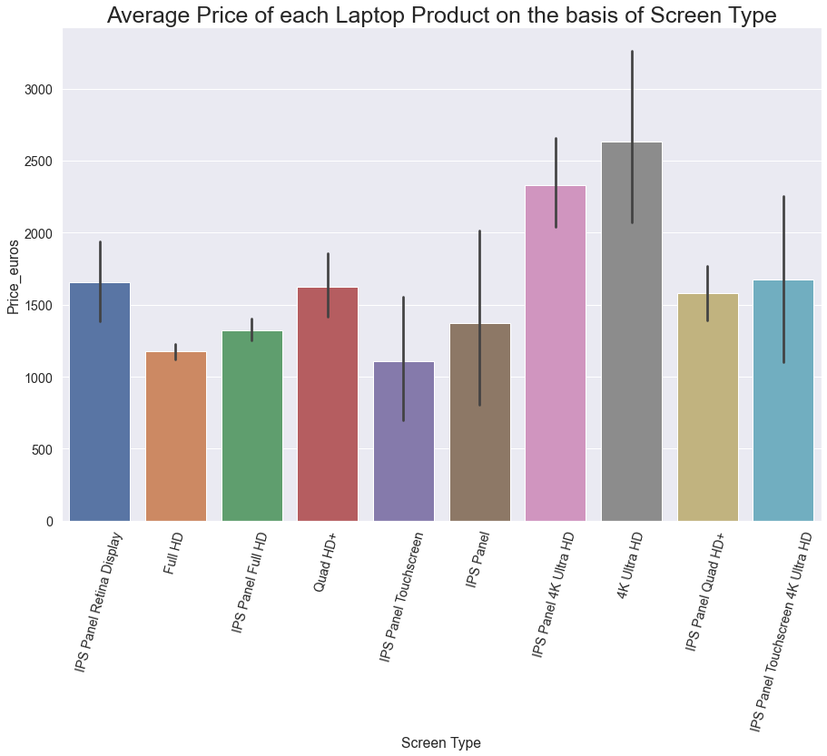

```python
Screen_withoutNone = df[df['Screen Type'] != 'None']
plt.xticks(rotation=75)
sns.barplot(x=Screen_withoutNone['Screen Type'], y=df['Price_euros']).set_title('Average Price of each Laptop Product on the basis of Screen Type', fontsize = 25)
Screen_withoutNone.groupby('Screen Type')['Price_euros'].mean()
```

We can see that laptops with 4K Ultra HD cost a lot, followed by IPS Panel 4K Ultra HD, the cheapest being the ones with IPS Panel Touchscreen. For all normal purposes Full HD screen or an IPS full HD screen is sufficient.

#### Now let us look at the Average Price of each laptop based on their Operating System

```
OpSys
Android          434.00
Chrome OS        553.59
Linux            617.07
Mac OS X        1262.87
No OS            587.97
Windows 10      1168.14
Windows 10 S    1286.48
Windows 7       1686.65
macOS           1749.63
Name: Price_euros, dtype: float64
```

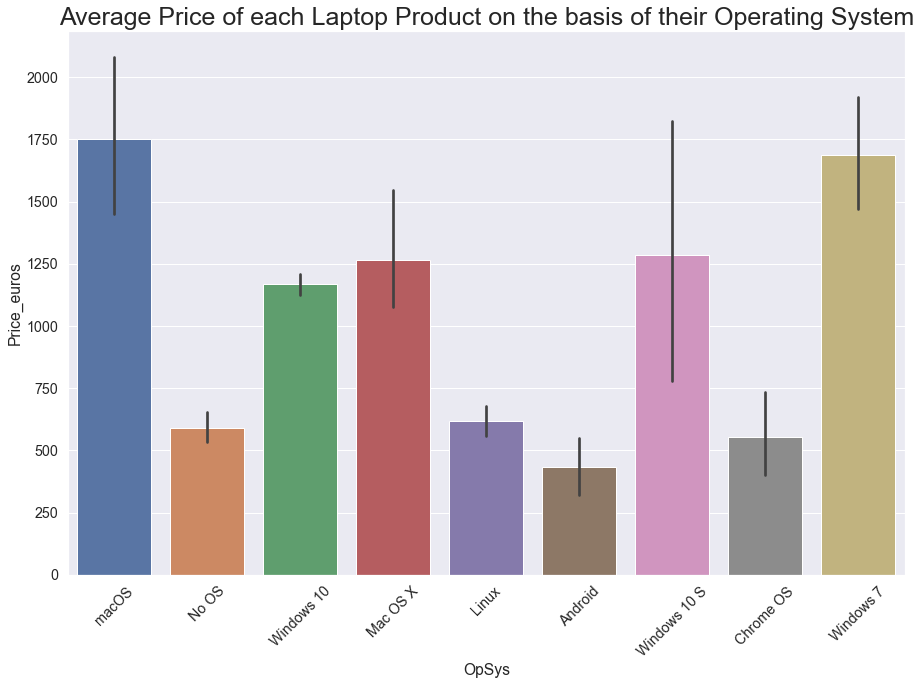

```python
plt.xticks(rotation=45)
sns.barplot(x=df['OpSys'], y=df['Price_euros']).set_title('Average Price of each Laptop Product on the basis of their Operating System', fontsize = 25)
df.groupby('OpSys')['Price_euros'].mean()
```

We can see MacOS has more asking price than the rest of the Operating System, this makes sense since MacOS is the proprietary software of Apple and is only available in their laptops(Macbooks), and Macbooks tend to be a bit on the costly side unlike Windows 10 which is available in almost all the laptops being costly or cheap. The lowest being Android, since many do not prefer Android in laptops.

#### Now let us look at the Average Price of each laptop based on it's Memory

```
Primary Memory (GB)  Primary Memory Type  Secondary Memory (GB)  Secondary Memory Type
64                   Flash Storage        1024.0                 HDD                      1993.00
128                  SSD                  1024.0                 HDD                      1266.82
                                          2048.0                 HDD                       977.95
256                  SSD                  256.0                  SSD                      1288.50
                                          500.0                  HDD                      1497.17
                                          1024.0                 HDD                      1856.15
                                                                 Hybrid                   2749.99
                                          2048.0                 HDD                      1535.91
512                  SSD                  256.0                  SSD                      1607.96
                                          512.0                  SSD                      1499.00
                                          1024.0                 HDD                      2500.45
                                                                 Hybrid                   3240.00
                                          2048.0                 HDD                      1849.00
1024                 HDD                  1024.0                 HDD                       621.45
                     SSD                  1024.0                 HDD                      3624.10
Name: Price_euros, dtype: float64
```

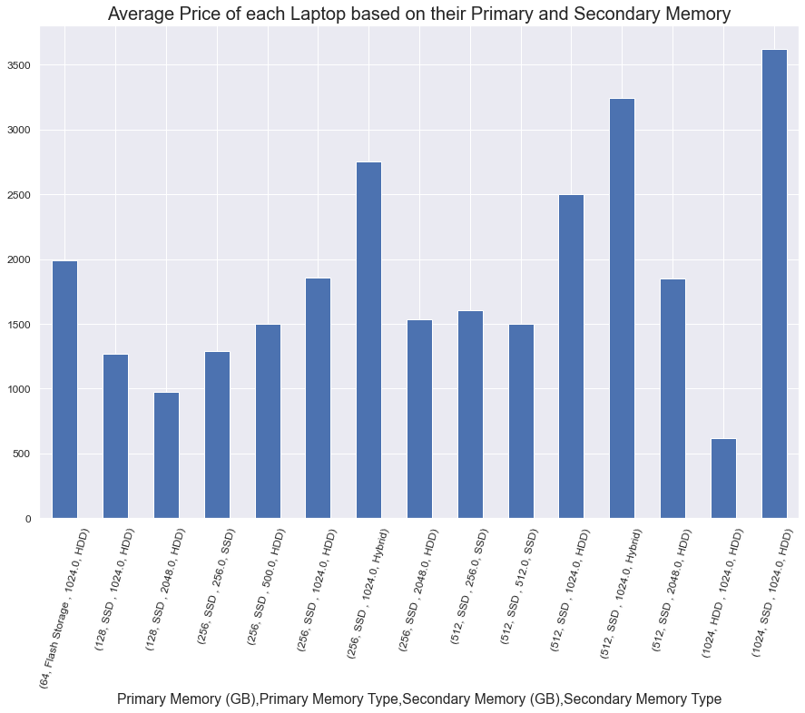

```python
plt.title("Average Price of each Laptop based on their Primary and Secondary Memory", fontsize=20)
Memory_price = df.groupby(['Primary Memory (GB)','Primary Memory Type','Secondary Memory (GB)','Secondary Memory Type'])['Price_euros'].mean()
Memory_price.plot(kind = 'bar', figsize = (15,10), rot = 75, fontsize = 12)
print(Memory_price)
plt.show()
```

From the bar plot we can see that 1024 GB SSD as primary memory and 1024 GB HDD as the secondary memory have the highest price while the lowest being 1024 GB HDD as primary memory and 1024 GB HDD as the secondary memory, the reason for which lies on the cost of SDD's. SDD's are very fast and effective at data writing and retrieval then the traditional HDD, and due to this fact they are very expensive than the traditional HDD. It is to strike a balance between the performance gains and the cost that people usually prefer 128 GB SDD as their primary memory and 2048 GB HDD as their secondary memory, which is also evident from the above bar plot, being the next cheapest option after 1024 GB HDD primary memory and 1024 GB HDD secondary memory.

### Saving our preprocessed dataset as a .csv file

```python
# Now that we have done the required preprocessing and some data analysis(where we were able to arrive at some useful conclusions) we now
# proceed to saving the preprocessed dataset to use in training our models, we save our model for the sole reason being that we would not
# have to go through the entire process above again while training and testing our model.

df.to_csv('Laptop_data_Preprocessed.csv', index = False)
```

## Building regression models and testing them

```python
# Reading the dataset containing the preprocessed data obtained from above

df = pd.read_csv('Laptop_data_Preprocessed.csv')
df
```

|  | laptop_ID | Company | Product | TypeName | Inches | Screen Width | Screen Height | Screen Type | TouchScreen | Cpu Vendor | Cpu Type | Cpu Series | Cpu Model | Cpu Speed (GHz) | Ram (GB) | Primary Memory (GB) | Primary Memory Type | Secondary Memory (GB) | Secondary Memory Type | Gpu Vendor | Gpu Model | OpSys | Weight (Kg) | Price_euros |
| --- | --- | --- | --- | --- | --- | --- | --- | --- | --- | --- | --- | --- | --- | --- | --- | --- | --- | --- | --- | --- | --- | --- | --- | --- |
| 0 | 1 | Apple | MacBook Pro | Ultrabook | 13.3 | 2560 | 1600 | IPS Panel Retina Display | No | Intel | Core | i5 | None | 2.3 | 8 | 128 | SSD | None | NaN | Intel | Iris Plus Graphics 640 | macOS | 1.37 | 1339.69 |
| 1 | 2 | Apple | Macbook Air | Ultrabook | 13.3 | 1440 | 900 | None | No | Intel | Core | i5 | None | 1.8 | 8 | 128 | Flash Storage | None | NaN | Intel | HD Graphics 6000 | macOS | 1.34 | 898.94 |
| 2 | 3 | HP | 250 G6 | Notebook | 15.6 | 1920 | 1080 | Full HD | No | Intel | Core | i5 | 7200U | 2.5 | 8 | 256 | SSD | None | NaN | Intel | HD Graphics 620 | No OS | 1.86 | 575.00 |
| 3 | 4 | Apple | MacBook Pro | Ultrabook | 15.4 | 2880 | 1800 | IPS Panel Retina Display | No | Intel | Core | i7 | None | 2.7 | 16 | 512 | SSD | None | NaN | AMD | Radeon Pro 455 | macOS | 1.83 | 2537.45 |
| 4 | 5 | Apple | MacBook Pro | Ultrabook | 13.3 | 2560 | 1600 | IPS Panel Retina Display | No | Intel | Core | i5 | None | 3.1 | 8 | 256 | SSD | None | NaN | Intel | Iris Plus Graphics 650 | macOS | 1.37 | 1803.60 |
| ... | ... | ... | ... | ... | ... | ... | ... | ... | ... | ... | ... | ... | ... | ... | ... | ... | ... | ... | ... | ... | ... | ... | ... | ... |
| 1298 | 1316 | Lenovo | Yoga 500-14ISK | 2 in 1 Convertible | 14.0 | 1920 | 1080 | IPS Panel Full HD | Yes | Intel | Core | i7 | 6500U | 2.5 | 4 | 128 | SSD | None | NaN | Intel | HD Graphics 520 | Windows 10 | 1.80 | 638.00 |
| 1299 | 1317 | Lenovo | Yoga 900-13ISK | 2 in 1 Convertible | 13.3 | 3200 | 1800 | IPS Panel Quad HD+ | Yes | Intel | Core | i7 | 6500U | 2.5 | 16 | 512 | SSD | None | NaN | Intel | HD Graphics 520 | Windows 10 | 1.30 | 1499.00 |
| 1300 | 1318 | Lenovo | IdeaPad 100S-14IBR | Notebook | 14.0 | 1366 | 768 | None | No | Intel | Celeron | Dual Core | N3050 | 1.6 | 2 | 64 | Flash Storage | None | NaN | Intel | HD Graphics | Windows 10 | 1.50 | 229.00 |
| 1301 | 1319 | HP | 15-AC110nv (i7-6500U/6GB/1TB/Radeon | Notebook | 15.6 | 1366 | 768 | None | No | Intel | Core | i7 | 6500U | 2.5 | 6 | 1024 | HDD | None | NaN | AMD | Radeon R5 M330 | Windows 10 | 2.19 | 764.00 |
| 1302 | 1320 | Asus | X553SA-XX031T (N3050/4GB/500GB/W10) | Notebook | 15.6 | 1366 | 768 | None | No | Intel | Celeron | Dual Core | N3050 | 1.6 | 4 | 500 | HDD | None | NaN | Intel | HD Graphics | Windows 10 | 2.20 | 369.00 |

1303 rows × 24 columns

### Encoding the data, removing the unwanted features and scaling the data

Many machine learning algorithms cannot operate on label data directly. They require all input variables and output variables to be numeric.

In general, this is mostly a constraint of the efficient implementation of machine learning algorithms rather than hard limitations on the algorithms themselves.

This means that categorical data must be converted to a numerical form. If the categorical variable is an output variable, you may also want to convert predictions by the model back into a categorical form in order to present them or use them in some application and this is done in two ways either through Label Encoding or One-Hot Encoding.

1. Label Encoding Each unique category value is assigned an integer value.

   For example, “red” is 1, “green” is 2, and “blue” is 3.

   This is called a label encoding or an integer encoding and is easily reversible.

   For some variables, this may be enough for some it creates a problem that is a ML model assumes assumes higher the categorical value, better the category and this sometimes results in a model with less accuracy.

   The integer values have a natural ordered relationship between each other and machine learning algorithms may be able to understand and harness this relationship.
2. One-Hot Encoding For categorical variables where no such ordinal relationship exists, the integer encoding is not enough.

   In fact, using this encoding and allowing the model to assume a natural ordering between categories may result in poor performance or unexpected results (predictions halfway between categories).

   In this case, a one-hot encoding can be applied to the integer representation. This is where the integer encoded variable is removed and a new binary variable is added for each unique integer value.

```python
# Performing One-Hot Encoding on the column Cpu Vendor and Gpu Vendor

Onehot = OneHotEncoder(sparse = False)
Onehot.fit(df['Cpu Vendor'].unique().reshape(-1,1))
transformed = Onehot.transform(df['Cpu Vendor'].to_numpy().reshape(-1,1))
Vendors = pd.DataFrame(transformed, columns = ['Cpu_Vendor_'+ str(i.replace('x0_', '')) for i in Onehot.get_feature_names()])
Vendors = Vendors.drop(['Cpu_Vendor_Samsung'], axis=1)
df.insert(9, 'Cpu_Vendor_AMD', Vendors['Cpu_Vendor_AMD'])
df.insert(10, 'Cpu_Vendor_Intel', Vendors['Cpu_Vendor_Intel'])
df = df.drop(['Cpu Vendor'], axis = 1)

Onehot.fit(df['Gpu Vendor'].unique().reshape(-1,1))
transformed = Onehot.transform(df['Gpu Vendor'].to_numpy().reshape(-1,1))
Vendors = pd.DataFrame(transformed, columns = ['Gpu_Vendor_'+ str(i.replace('x0_', '')) for i in Onehot.get_feature_names()])
Vendors = Vendors.drop(['Gpu_Vendor_ARM'], axis=1)
df.insert(21, 'Gpu_Vendor_AMD', Vendors['Gpu_Vendor_AMD'])
df.insert(22, 'Gpu_Vendor_Intel', Vendors['Gpu_Vendor_Intel'])
df.insert(23, 'Gpu_Vendor_Nvidia', Vendors['Gpu_Vendor_Nvidia'])
df = df.drop(['Gpu Vendor'], axis = 1)

# Dropping the column laptop_ID since it is just used to identify the product(serves as an index) and has no relevance in the training

df = df.drop(['laptop_ID'], axis = 1)
df
```

|  | Company | Product | TypeName | Inches | Screen Width | Screen Height | Screen Type | TouchScreen | Cpu_Vendor_AMD | Cpu_Vendor_Intel | Cpu Type | Cpu Series | Cpu Model | Cpu Speed (GHz) | Ram (GB) | Primary Memory (GB) | Primary Memory Type | Secondary Memory (GB) | Secondary Memory Type | Gpu_Vendor_AMD | Gpu_Vendor_Intel | Gpu_Vendor_Nvidia | Gpu Model | OpSys | Weight (Kg) | Price_euros |
| --- | --- | --- | --- | --- | --- | --- | --- | --- | --- | --- | --- | --- | --- | --- | --- | --- | --- | --- | --- | --- | --- | --- | --- | --- | --- | --- |
| 0 | Apple | MacBook Pro | Ultrabook | 13.3 | 2560 | 1600 | IPS Panel Retina Display | No | 0.0 | 1.0 | Core | i5 | None | 2.3 | 8 | 128 | SSD | None | NaN | 0.0 | 1.0 | 0.0 | Iris Plus Graphics 640 | macOS | 1.37 | 1339.69 |
| 1 | Apple | Macbook Air | Ultrabook | 13.3 | 1440 | 900 | None | No | 0.0 | 1.0 | Core | i5 | None | 1.8 | 8 | 128 | Flash Storage | None | NaN | 0.0 | 1.0 | 0.0 | HD Graphics 6000 | macOS | 1.34 | 898.94 |
| 2 | HP | 250 G6 | Notebook | 15.6 | 1920 | 1080 | Full HD | No | 0.0 | 1.0 | Core | i5 | 7200U | 2.5 | 8 | 256 | SSD | None | NaN | 0.0 | 1.0 | 0.0 | HD Graphics 620 | No OS | 1.86 | 575.00 |
| 3 | Apple | MacBook Pro | Ultrabook | 15.4 | 2880 | 1800 | IPS Panel Retina Display | No | 0.0 | 1.0 | Core | i7 | None | 2.7 | 16 | 512 | SSD | None | NaN | 1.0 | 0.0 | 0.0 | Radeon Pro 455 | macOS | 1.83 | 2537.45 |
| 4 | Apple | MacBook Pro | Ultrabook | 13.3 | 2560 | 1600 | IPS Panel Retina Display | No | 0.0 | 1.0 | Core | i5 | None | 3.1 | 8 | 256 | SSD | None | NaN | 0.0 | 1.0 | 0.0 | Iris Plus Graphics 650 | macOS | 1.37 | 1803.60 |
| ... | ... | ... | ... | ... | ... | ... | ... | ... | ... | ... | ... | ... | ... | ... | ... | ... | ... | ... | ... | ... | ... | ... | ... | ... | ... | ... |
| 1298 | Lenovo | Yoga 500-14ISK | 2 in 1 Convertible | 14.0 | 1920 | 1080 | IPS Panel Full HD | Yes | 0.0 | 1.0 | Core | i7 | 6500U | 2.5 | 4 | 128 | SSD | None | NaN | 0.0 | 1.0 | 0.0 | HD Graphics 520 | Windows 10 | 1.80 | 638.00 |
| 1299 | Lenovo | Yoga 900-13ISK | 2 in 1 Convertible | 13.3 | 3200 | 1800 | IPS Panel Quad HD+ | Yes | 0.0 | 1.0 | Core | i7 | 6500U | 2.5 | 16 | 512 | SSD | None | NaN | 0.0 | 1.0 | 0.0 | HD Graphics 520 | Windows 10 | 1.30 | 1499.00 |
| 1300 | Lenovo | IdeaPad 100S-14IBR | Notebook | 14.0 | 1366 | 768 | None | No | 0.0 | 1.0 | Celeron | Dual Core | N3050 | 1.6 | 2 | 64 | Flash Storage | None | NaN | 0.0 | 1.0 | 0.0 | HD Graphics | Windows 10 | 1.50 | 229.00 |
| 1301 | HP | 15-AC110nv (i7-6500U/6GB/1TB/Radeon | Notebook | 15.6 | 1366 | 768 | None | No | 0.0 | 1.0 | Core | i7 | 6500U | 2.5 | 6 | 1024 | HDD | None | NaN | 1.0 | 0.0 | 0.0 | Radeon R5 M330 | Windows 10 | 2.19 | 764.00 |
| 1302 | Asus | X553SA-XX031T (N3050/4GB/500GB/W10) | Notebook | 15.6 | 1366 | 768 | None | No | 0.0 | 1.0 | Celeron | Dual Core | N3050 | 1.6 | 4 | 500 | HDD | None | NaN | 0.0 | 1.0 | 0.0 | HD Graphics | Windows 10 | 2.20 | 369.00 |

1303 rows × 26 columns

```python
# Encoding the columns using their Label(Label Encoding) after ordering each column based on the price

col = ['Company', 'Product', 'TypeName', 'Screen Type', 'Cpu Type', 'Cpu Series', 'Gpu Model', 'OpSys']
for feature in col:
    labels_ordered= df.groupby([feature])['Price_euros'].mean().sort_values().index
    labels_ordered={k:i for i,k in enumerate(labels_ordered,0)}
    df[feature]=df[feature].map(labels_ordered)

# Encoding the value of the column TouchScreen as 1 if it has the value 'Yes' else 0

df['TouchScreen'] = df['TouchScreen'].map({'Yes': 1, 'No': 0})

# Replacing the value of the column 'Secondary Memory (GB)' with 0.0 if the laptop has no secondary memory

df['Secondary Memory (GB)'] = df['Secondary Memory (GB)'].replace('None', 0.0)

df.head()
```

|  | Company | Product | TypeName | Inches | Screen Width | Screen Height | Screen Type | TouchScreen | Cpu_Vendor_AMD | Cpu_Vendor_Intel | Cpu Type | Cpu Series | Cpu Model | Cpu Speed (GHz) | Ram (GB) | Primary Memory (GB) | Primary Memory Type | Secondary Memory (GB) | Secondary Memory Type | Gpu_Vendor_AMD | Gpu_Vendor_Intel | Gpu_Vendor_Nvidia | Gpu Model | OpSys | Weight (Kg) | Price_euros |
| --- | --- | --- | --- | --- | --- | --- | --- | --- | --- | --- | --- | --- | --- | --- | --- | --- | --- | --- | --- | --- | --- | --- | --- | --- | --- | --- |
| 0 | 13 | 559 | 3 | 13.3 | 2560 | 1600 | 7 | 0 | 0.0 | 1.0 | 12 | 27 | None | 2.3 | 8 | 128 | SSD | 0.0 | NaN | 0.0 | 1.0 | 0.0 | 80 | 8 | 1.37 | 1339.69 |
| 1 | 13 | 333 | 3 | 13.3 | 1440 | 900 | 0 | 0 | 0.0 | 1.0 | 12 | 27 | None | 1.8 | 8 | 128 | Flash Storage | 0.0 | NaN | 0.0 | 1.0 | 0.0 | 45 | 8 | 1.34 | 898.94 |
| 2 | 5 | 107 | 1 | 15.6 | 1920 | 1080 | 2 | 0 | 0.0 | 1.0 | 12 | 27 | 7200U | 2.5 | 8 | 256 | SSD | 0.0 | NaN | 0.0 | 1.0 | 0.0 | 54 | 2 | 1.86 | 575.00 |
| 3 | 13 | 559 | 3 | 15.4 | 2880 | 1800 | 7 | 0 | 0.0 | 1.0 | 12 | 29 | None | 2.7 | 16 | 512 | SSD | 0.0 | NaN | 1.0 | 0.0 | 0.0 | 95 | 8 | 1.83 | 2537.45 |
| 4 | 13 | 559 | 3 | 13.3 | 2560 | 1600 | 7 | 0 | 0.0 | 1.0 | 12 | 27 | None | 3.1 | 8 | 256 | SSD | 0.0 | NaN | 0.0 | 1.0 | 0.0 | 84 | 8 | 1.37 | 1803.60 |

### Visualizing the dataset using a Heat-map

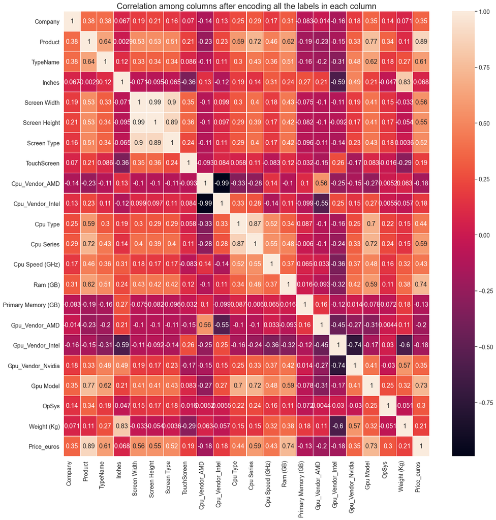

```python
# Displaying the heatmap to see the relationships of each feature wrt other features

plt.figure()
plt.figure(figsize = (20,20))
plt.title('Correlation among columns after encoding all the labels in each column',fontsize = 20)
laptop = sns.heatmap(df.corr(), annot=True, linewidths=.1)
laptop.set_xticklabels(laptop.get_xticklabels(), rotation=90, horizontalalignment='right')
plt.show()
```

From the above heat-map we can see that the company, Product, Typename(Laptop Type), Screen Width and Screen Height, Screen Type, Cpu_Vendor, Cpu_Type, Cpu Series, Cpu Speed, Ram, Gpu_Vendor, Gpu Model, Opsys and weight have a good relationship with the Price and can be used to predict price effectively. In the head-map we did before this we were not able to get such a detailed relationship chart since many features where categorical in nature then, but now since we had converted them into numerical with Label Encoding and One-Hot Encoding we are able to see the detailed relationship.

### Splitting and assigning the data

```python
# Assigning the values to X and y so that we can use them to train our model

X = df.drop(columns = ['Price_euros', 'Cpu Model', 'Primary Memory Type', 'Secondary Memory Type'])
y = df['Price_euros']
```

```python
# Using Standard Scaler to remove the mean and scales each feature to unit variance.

scaler  = StandardScaler()
temp = scaler.fit_transform(X)
X = pd.DataFrame(temp)
```

Standardization is a scaling technique where the values are centered around the mean with a unit standard deviation. This means that the mean of the attribute becomes zero and the resultant distribution has a unit standard deviation.

This is done so that the variance of the features are in the same range. If a feature’s variance is orders of magnitude more than the variance of other features, that particular feature might dominate other features in the dataset, which is not something we want happening in our model.

The aim here is to to achieve Gaussian with zero mean and unit variance. There are many ways of doing this, two most popular are standardisation and normalisation.

```python
# Spliting out dataset into train and test (80/20 split)

X_train, X_test, y_train, y_test = train_test_split(X, y, test_size = 0.2, random_state = 42, shuffle = True)
```

```python
# Defining the mean absolute percentage error function (a metric used for testing the performance of our model)

def mean_abs_percent_error(x):
    mae = mean_absolute_error(x,y_test)
    mean = y_test.mean()
    percentage_mae = (mae/mean)*100
    return percentage_mae
```

The mean absolute percentage error (MAPE), also known as mean absolute percentage deviation (MAPD), is a measure of prediction accuracy of a forecasting method.

The closer it is to 0 the better is the prediction capability of our model with 0 being the ideal case.

The coefficient of determination, denoted R2 or r2 and pronounced "R squared", is the proportion of the variance in the dependent variable that is predictable from the independent variable and is an effective measure to check the accuracy of the model.

The closer the value is to 1 the better is the prediction capability of our model with 1 being the ideal case.